# The Effect of Vitamin C on Tooth Growth in Guinea Pigs

Tejus

20/09/2020

### Overview :

- We would like to look at the following Tooth growth data and do some basic statistics.
- First the data was looked at and then based on mean & variance for each category we decided the test statistic to be computed.
- After significance testing we have also made some inferences about the data in the last section of results & inferences.

Tooth_Growth Data :

- A data frame with 60 observations on 3 variables.
- 60 guinea pigs (unpaired/ independent groups). Each animal received one of three dose levels of vitamin C (0.5, 1, and 2 mg/day) by 1 of the following delivery methods.
- Two delivery methods, orange juice (coded as ‘OJ’) or ascorbic acid (a form of vitamin C and coded as ‘VC’).

### Basic exploratory data analyses

```r
head(ToothGrowth)
```

```
##     len supp dose
## 1:  4.2   VC  0.5
## 2: 11.5   VC  0.5
## 3:  7.3   VC  0.5
## 4:  5.8   VC  0.5
## 5:  6.4   VC  0.5
## 6: 10.0   VC  0.5
```

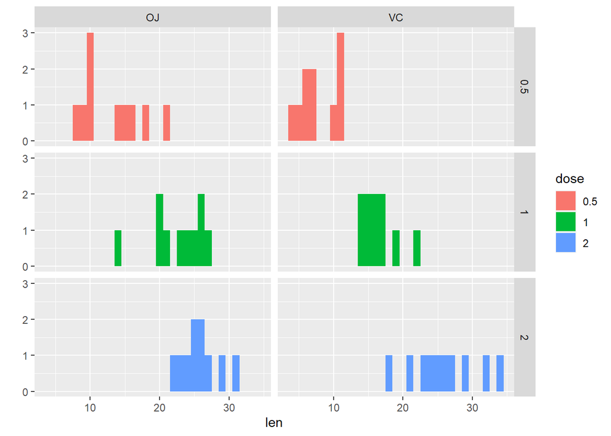

Histogram according to each of the variables; Vehicle & Dosage

```r
qplot(len, data=ToothGrowth, facets = dose~supp, fill = dose, binwidth = 1)
```

### Basic summary of the data.

**Mean of the data**

| Dose | OJ | VC | Total |
| --- | --- | --- | --- |
| 0.5 | 13.23 | 7.98 | 21.21 |
| 1 | 22.70 | 16.77 | 39.47 |
| 2 | 26.06 | 26.14 | 52.20 |

**Variance of the data**

| Dose | OJ | VC | Total |
| --- | --- | --- | --- |
| 0.5 | 19.889000 | 7.544000 | 27.43300 |
| 1 | 15.295556 | 6.326778 | 21.62233 |
| 2 | 7.049333 | 23.018222 | 30.06756 |

### Tooth growth by method of administration

Let us now see if the difference between the 2 administration methods are significantly different from each other using a 2 sample T-test. Since the variance doesn’t seem equal from the above table we will also do Welch T-Test (In t.test Fn set this param `var.equal = FALSE`)

**Assumptions**

- Since the sample size is small we will assume the `len` variable follows a T distribution.
- Variance also is high between the 2 groups hence the Welch test.
- Let our alternate hypothesis `Ho : Mean length of OJ > Mean length of VC`.
- Thus our null hypothesis becomes `Ha : Mean length of OJ !> Mean length of VC`.

[output not shown]

**Conclusion :**

Orange juice `'OJ'` delivery of Vitamin C has shown significant growth of odontoblasts compared to Ascorbic acid `'VC'`

### Tooth growth by dose

Let us now see if the difference between the different dosages are significant from each other using a 2 sample T-test. Since the variance doesn’t seem equal from the above table we will also do Welch T-Test (In t.test Fn set this param `var.equal = FALSE`)

**Assumptions** - Since the sample size is small we will assume the `len` variable follows a T distribution.  
- Variance also is high between the 2 groups hence the Welch test with unequal variances.

1.) Dose 0.5 mg/day V/S Dose 1 mg/day

- Let our alternate hypothesis `Ho : Mean length for 1mg/day dose > Mean length for 0.5mg/day`.
- Thus our null hypothesis becomes `Ha : Mean length for 1mg/day !> Mean length for 0.5mg/day`.

```r
D1 <- (ToothGrowth[dose == "0.5",1])$len
D2 <- (ToothGrowth[dose == "1",1])$len
D3 <- (ToothGrowth[dose == "2",1])$len

t.test(D2, D1, paired = FALSE, conf.level = 0.95, var.equal = FALSE, alternative = "greater")
```

```
##
##  Welch Two Sample t-test
##
## data:  D2 and D1
## t = 6.4766, df = 37.986, p-value = 6.342e-08
## alternative hypothesis: true difference in means is greater than 0
## 95 percent confidence interval:
##  6.753323      Inf
## sample estimates:
## mean of x mean of y
##    19.735    10.605
```

- Since our p value 6.341503610^{-8} is well below `< 0.05` we can reject the `Ho hypothesis` with 95% confidence as there is only a 6.341503610^{-6}% chance of the difference observed (between Dose 1 mg/day & Dose 0.5 mg/day) being from Null distribution.

**Conclusion :**  
Dose `'1 mg/day'` of Vitamin C has shown significant growth of odontoblasts compared to Dose `'0.5 mg/day'`

2.) Dose 1 mg/day V/S Dose 2 mg/day

Since their mean lengths are close in values we will see if there is any difference in their means using a 2 sided hypothesis test.

- Let our alternate hypothesis `Ho : Mean length for dose 1mg/day != Mean length of 2 mg/day`.
- Thus our null hypothesis becomes `Ha : Mean length for 1mg/day == Mean length of 2mg/day`.

```r
t.test(D3, D2, paired = FALSE, conf.level = 0.95, var.equal = FALSE)
```

```
##
##  Welch Two Sample t-test
##
## data:  D3 and D2
## t = 4.9005, df = 37.101, p-value = 1.906e-05
## alternative hypothesis: true difference in means is not equal to 0
## 95 percent confidence interval:
##  3.733519 8.996481
## sample estimates:
## mean of x mean of y
##    26.100    19.735
```

**Conclusion :**  
Dose `'2 mg/day'` of Vitamin C has shown significant growth of odontoblasts compared to Dose `'1 mg/day'`

### Results & inferences

Below conclusions satisfy p value cutoff of 0.05 or with 95% confidence we can say.

- Dose `'1 mg/day'` of Vitamin C has shown significant growth of odontoblasts compared to Dose `'0.5 mg/day'`
- Dose `'2 mg/day'` of Vitamin C has shown significant growth of odontoblasts compared to Dose `'1 mg/day'`. Since dose 1 mg/day is greater than 0.5mg/day and 2mg/day > 1mg/day we can conclude the best dose to be **2mg/day**.
- Orange juice `'OJ'` delivery of Vitamin C has shown significant growth of odontoblasts compared to Ascorbic acid `'VC'`

Note : All of the above inferences have been made assuming the groups are independent with unequal variances between the groups. Since the sample size was also small we assumed the variable follows T-distribution.